# Project 2: Heatwave analysis for Italy

**Member of Group**

- *AKONAKPO SEDJRO*
- *KOOVI NOELIE*
- *KOUKPONOU SONAGNON*

The goal through this project is to examine consequences of the summer 2022 heatwave for Italy.

This project is loosely based on [Ballester et al. (2023)](https://ametice.univ-amu.fr/mod/resource/view.php?id=4030736) who conduct a quantitative analysis of the mortality-temperature relationship using the NUTS3 spatial resolution (both for mortality figures and ERA5 temperature scans).

Here, we will use mortality data for the whole of Italy, so results will differ from those of Ballester et al. (2023).

```r
# loading necessary packages
library(tidyverse)
library(lubridate)
library(readr)
library(ggplot2)
library(scales)
library(gridExtra)
library(ISOweek)
```

## 1. Load and Visualize Temperature Data

```r
# Load temperature dataset
temp_data <- read_csv("/Applications/Documents/Master 1 Econométrie Statistique/Semestre 2/Data_Viz_S2/Data/Final/Temperature_week_data.csv")%>%
  rename(start_date = week)
```

### Outlier Detection and Distribution

Let me explore briefly this data

```r
glimpse(temp_data)
```

```
## Rows: 470
## Columns: 2
## $ start_date <date> 2014-12-29, 2015-01-05, 2015-01-12, 2015-01-19, 2015-01-26…
## $ t2m        <dbl> 8.340602, 9.507697, 10.645698, 9.500419, 7.616689, 7.526555…
```

```r
colSums(is.na(temp_data))
```

```
## start_date        t2m
##          0          0
```

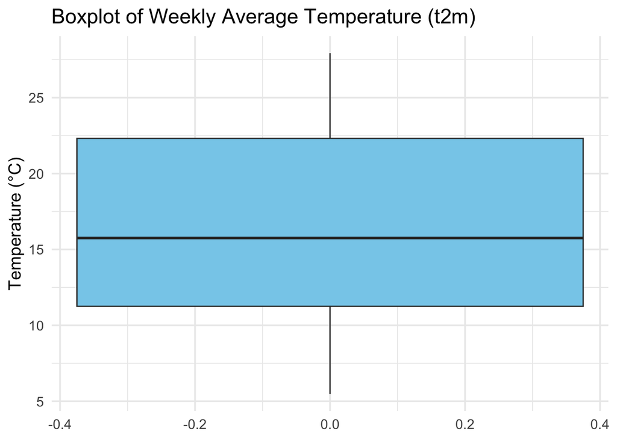

```r
# Boxplot for temperature
ggplot(temp_data, aes(y = t2m)) +
  geom_boxplot(fill = "skyblue") +
  labs(title = "Boxplot of Weekly Average Temperature (t2m)", y = "Temperature (°C)") +
  theme_minimal(base_size = 14)
```

We don’t have missing value. After plotting the box plot and the distribution of the temperature, we see that we don’t have outliers in the data.

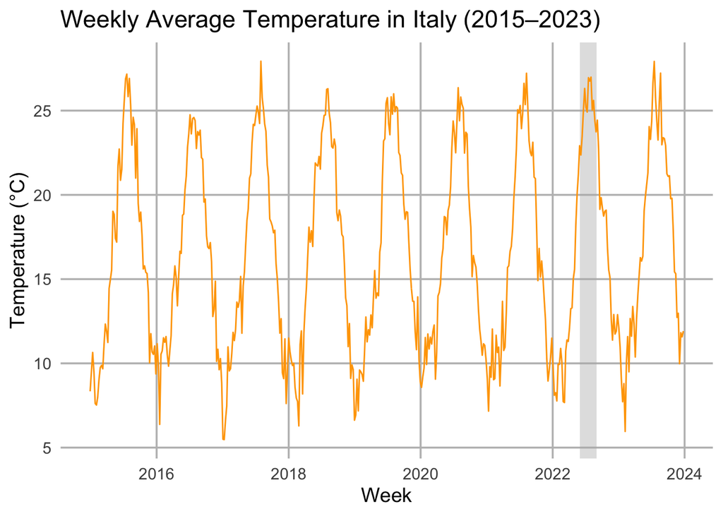

```r
summer_2022 <- data.frame(
  start = as.Date("2022-06-01"),
  end = as.Date("2022-08-31")
)

ggplot(temp_data, aes(x = start_date, y = t2m)) +
  geom_rect(
    data = summer_2022,
    aes(xmin = start, xmax = end, ymin = -Inf, ymax = Inf),
    fill = "grey70", alpha = 0.4, inherit.aes = FALSE
  ) +
  geom_line(color = "#FFA500", linewidth = 0.5) +
  labs(
    title = "Weekly Average Temperature in Italy (2015–2023)",
    x = "Week",
    y = "Temperature (°C)"
  ) +
  theme_minimal(base_size = 14) +
  theme(
    panel.grid.major = element_line(color = "grey"),
    panel.grid.minor = element_blank()
  )
```

## 2. Loading and Filtering Mortality Data

```r
# Load World Mortality Dataset
mortality_data <- read_csv("https://raw.githubusercontent.com/akarlinsky/world_mortality/main/world_mortality.csv")
```

The [World Mortality Dataset](https://github.com/akarlinsky/world_mortality) is compiled by Ariel Karlinsky and Dmitry Kobak. It records all-cause mortality at a weekly level for 127 countries and territories in 2015–2024 collected from various sources,

```r
# Filtering
mortality <- mortality_data %>%
  filter(iso3c == "ITA") %>%
  select(-c(iso3c, country_name, time_unit)) %>%
  rename(mortality = deaths, week = time) %>%
   mutate(
    iso_week = paste0(year, "-W", sprintf("%02d", week), "-1"),
    start_date = ISOweek2date(iso_week)
  )%>%
  select(-iso_week)
# we don't have the function get_date. In place of this function, we use ISOweek2date which an alternative.
```

### - Outlier Detection and Distribution for Mortality dataset

```r
glimpse(mortality)
```

```
## Rows: 522
## Columns: 4
## $ year       <dbl> 2015, 2015, 2015, 2015, 2015, 2015, 2015, 2015, 2015, 2015,…
## $ week       <dbl> 1, 2, 3, 4, 5, 6, 7, 8, 9, 10, 11, 12, 13, 14, 15, 16, 17, …
## $ mortality  <dbl> 15178, 15811, 15480, 14922, 15228, 15640, 15510, 15149, 145…
## $ start_date <date> 2014-12-29, 2015-01-05, 2015-01-12, 2015-01-19, 2015-01-26…
```

```r
colSums(is.na(mortality))
```

```
##       year       week  mortality start_date
##          0          0          0          0
```

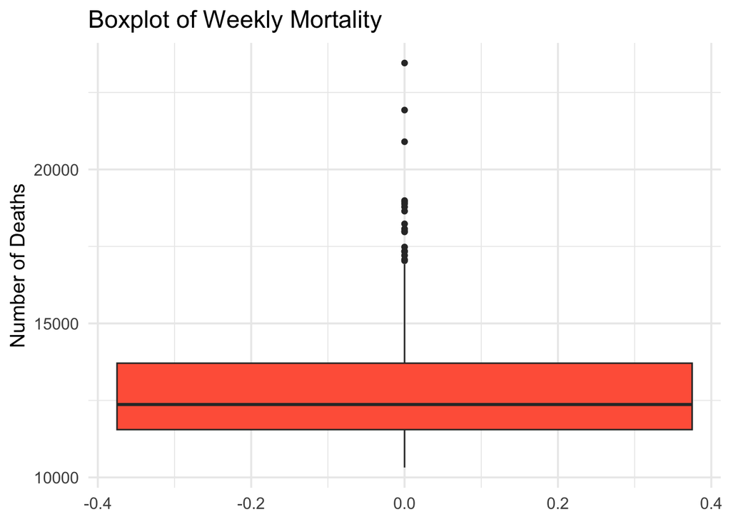

```r
# Boxplot for mortality
ggplot(mortality, aes(y = mortality)) +
  geom_boxplot(fill = "tomato") +
  labs(title = "Boxplot of Weekly Mortality", y = "Number of Deaths") +
  theme_minimal(base_size = 14)
```

Here, again, we have no missing value. The box plot shows the presence of a few outliers. BUT, Is it really outliers ? Let’s see this values more closely.

```r
Q1 <- quantile(mortality$mortality, 0.25, na.rm = TRUE)
Q3 <- quantile(mortality$mortality, 0.75, na.rm = TRUE)
IQR <- Q3 - Q1

lower_bound <- Q1 - 1.5 * IQR
upper_bound <- Q3 + 1.5 * IQR


outliers <- mortality %>%
  filter(mortality < lower_bound | mortality > upper_bound)

print(outliers)
```

```
## # A tibble: 18 × 4
##     year  week mortality start_date
##    <dbl> <dbl>     <dbl> <date>
##  1  2017     1     18072 2017-01-02
##  2  2017     2     18990 2017-01-09
##  3  2017     3     17973 2017-01-16
##  4  2020    11     18234 2020-03-09
##  5  2020    12     21929 2020-03-16
##  6  2020    13     23457 2020-03-23
##  7  2020    14     20901 2020-03-30
##  8  2020    15     18949 2020-04-06
##  9  2020    45     17335 2020-11-02
## 10  2020    46     18647 2020-11-09
## 11  2020    47     18784 2020-11-16
## 12  2020    48     18887 2020-11-23
## 13  2020    49     17995 2020-11-30
## 14  2020    50     17482 2020-12-07
## 15  2020    51     17073 2020-12-14
## 16  2021     3     17209 2021-01-18
## 17  2022     3     17035 2022-01-17
## 18  2022     4     17347 2022-01-24
```

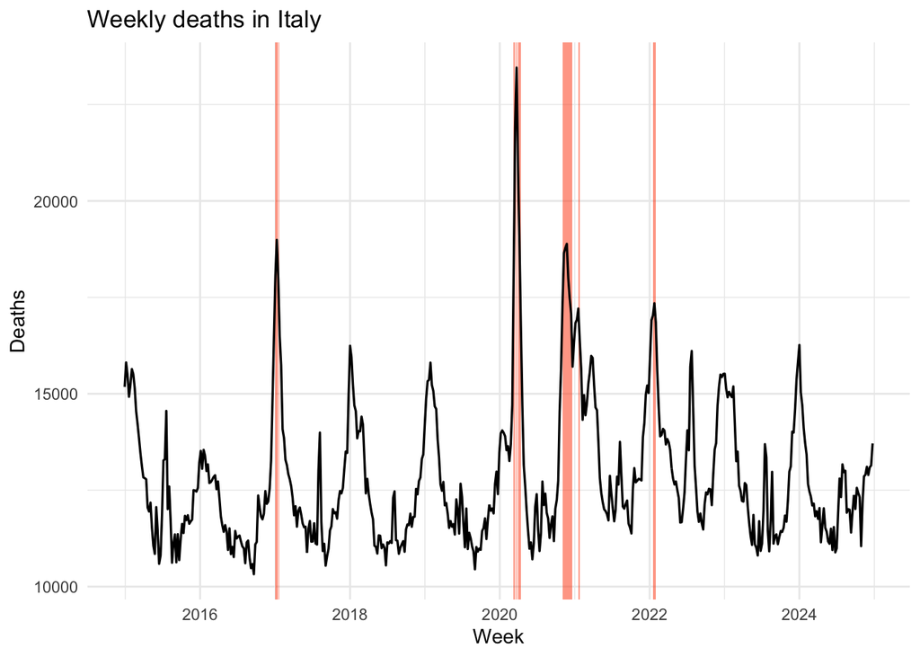

```r
outlier_periods <- outliers %>%
  mutate(end_date = start_date + 6) %>%
  select(start = start_date, end = end_date)

ggplot(mortality, aes(x = start_date, y = mortality)) +
  geom_rect(
    data = outlier_periods,
    aes(xmin = start, xmax = end, ymin = -Inf, ymax = Inf),
    fill = "#FF4500", alpha = 0.5,
    inherit.aes = FALSE
  ) +
  geom_line(color = "black", linewidth = 0.6) +
  labs(
    title = "Weekly deaths in Italy",
    x = "Week",
    y = "Deaths"
  ) +
  theme_minimal()
```

## 3. Estimate time-series Mortality Model

Then, we will estimate a simple time-series model of **excess mortality** for the period before *2020-03-01*, which only considers a linear year effect and week fixed effects. After the estimation, we will use the model to predict mortality for the *summer of 2022*, and compute the measure of excess mortality.

```r
# Restrict period (before March 1, 2020)
serie <- mortality %>% filter(start_date < as.Date("2020-03-01"))

# Create year and week variables
serie <- serie %>%
  mutate(year = year(start_date), week = isoweek(start_date))

# Fit linear model with year trend and week fixed effects
lm_base <- lm(mortality ~ year + factor(week), data = serie)
library(stargazer)
stargazer(lm_base, type = "text", title = "Linear mortality model")
```

```
##
## Linear mortality model
## ===============================================
##                         Dependent variable:
##                     ---------------------------
##                              mortality
## -----------------------------------------------
## year                          -50.626
##                              (33.272)
##
## factor(week)2                 354.813
##                              (465.308)
##
## factor(week)3                 182.480
##                              (465.308)
##
## factor(week)4                -277.854
##                              (465.308)
##
## factor(week)5                -380.187
##                              (465.308)
##
## factor(week)6                -835.520*
##                              (465.308)
##
## factor(week)7               -952.854**
##                              (465.308)
##
## factor(week)8              -1,234.354***
##                              (465.308)
##
## factor(week)9              -1,223.354***
##                              (465.308)
##
## factor(week)10             -1,511.100***
##                              (487.707)
##
## factor(week)11             -1,877.300***
##                              (487.707)
##
```

[output cut: 122 more lines]

```
##
## factor(week)53             -1,993.753**
##                              (872.496)
##
## Constant                   117,223.700*
##                            (67,109.770)
##
## -----------------------------------------------
## Observations                    270
## R2                             0.767
## Adjusted R2                    0.710
## Residual Std. Error     805.422 (df = 216)
## F Statistic          13.451*** (df = 53; 216)
## ===============================================
## Note:               *p<0.1; **p<0.05; ***p<0.01
```

The model adjusts weekly mortality according to a linear time trend (year) and fixed effects for each week of the year (factor(week)). Here are the interpretation of the core of the model :

(Intercept): No need to interpret it but we can say that the estimated mortality when year is 0 and week is the reference category (week 1, not explicitly shown) is 117223.71. Its p-value (0.082103) is marginally significant at the 10% level.

Year: Again, no need to interpret it because it is not statistically significant at any conventional level. But, for each one-year increase, the model estimates a decrease in mortality of approximately 50.63 units, holding the week constant.

Weekly fixed effects: Compared with week 1 (the reference), summer weeks (notably weeks 26 to 35) show significantly lower levels of mortality in the reference period.

For example, the week 2 has an estimate of 354.81, meaning that in week 2, mortality is estimated to be 354.81 units higher than in week 1, holding the year constant. However, This difference is not statistically significant. We can’t consider this effect.

Conversely, the week 12 has an estimate of -2379.70, indicating that in week 12, mortality is estimated to be 2379.70 units lower than in week 1, and this difference is highly statistically significant

In conclusion, you can see a general trend of lower mortality in many weeks compared to week 1, with several weeks showing statistically significant reductions.

Model quality:

Multiple R-squared: 0.7675 This indicates that approximately 76.75% of the total variance in mortality is explained by this linear model. So, the model explains the variation in weekly mortality well.

Adjusted R-squared: 0.7104 The R-squared is lower than the Multiple R-squared. It suggests that while adding the week factors increases the explained variance, some of that increase is due to the increased complexity of the model.

F-statistic: 13.45 on 53 and 216 DF, p-value: < 2.2e-16 The small p-value of F-statistic tests indicates that the model as a whole is highly statistically significant, meaning that year and factor(week) together explain a significant amount of the variation in mortality.

**To sum up, this linear model suggests that the week of the year has a statistically significant impact on mortality, with many weeks showing significantly lower mortality compared to the first week. The year shows a negative trend (a decrease in mortality over time), but this trend is not statistically significant at any level. The model explains a substantial portion of the variance in mortality, and the overall model is highly significant.**

### Predict 2022 Mortality and Compute Excess

```r
# Prepare prediction dataset (summer 2022 only)
summer_mort <- mortality %>%
  filter(start_date >= as.Date("2022-06-01"), start_date <= as.Date("2022-08-31")) %>%
  mutate(year = year(start_date), week = isoweek(start_date))

# Predict expected deaths
summer_mort$predicted <- predict(lm_base, newdata = summer_mort)

# Compute excess deaths
summer_mort <- summer_mort %>%
  mutate(excess = mortality - predicted)

# Total excess deaths in summer 2022
total_excess <- sum(summer_mort$excess, na.rm = TRUE)

# Print the result
print(paste("Total excess mortality for Summer 2022:", round(total_excess, 2)))
```

```
## [1] "Total excess mortality for Summer 2022: 26514.51"
```

During the summer of 2022 (June to August), Italy experienced an estimated 26,515 excess deaths. This means that the number of deaths during this period was significantly higher than expected based on data *before 2020-03-01*. This excess mortality may be related to extreme heat events or other health stressors that occurred during that summer. Nor should we forget that this was a pandemic period (COVID), even if deaths from covid were declining.

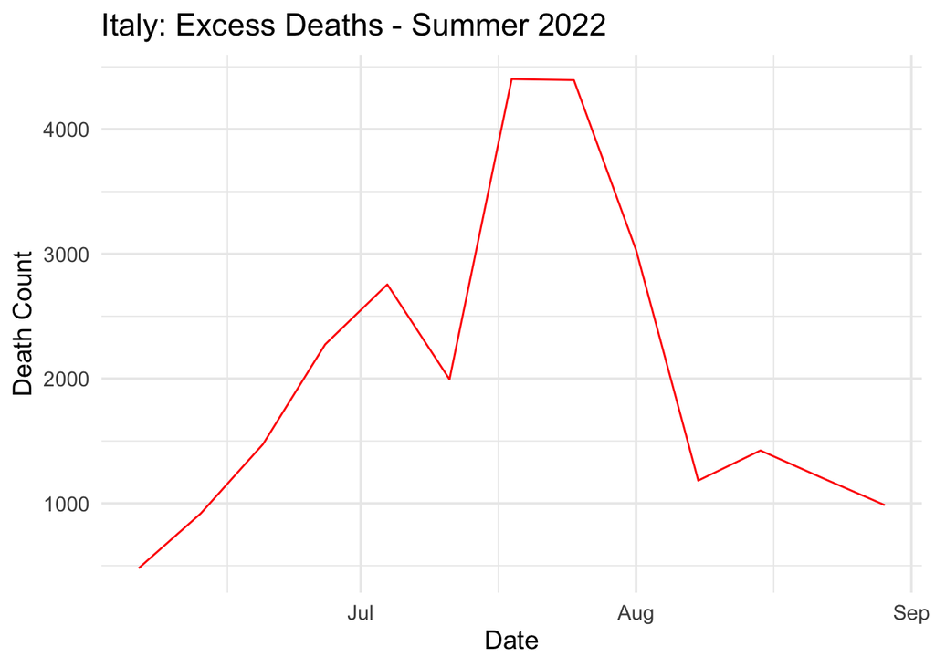

```r
# Plot observed excess deaths over time
ggplot(summer_mort, aes(x = start_date, y = excess)) +
  geom_line(color = "red", linewidth = 0.5) +
  labs(title = "Italy: Excess Deaths - Summer 2022",
       x = "Date", y = "Death Count") +
  theme_minimal(base_size = 14)
```